# cellcount: an open-source and automated approach to cyanobacteria enumeration

Tyler E. Harman (Consolidated Safety Services, Fairfax, VA 22031, USA National Oceanic and Atmospheric Administration, National Centers for Coastal Ocean Science, Beaufort, NC 28516, USA) , Mark W. Vandersea (National Oceanic and Atmospheric Administration, National Centers for Coastal Ocean Science, Beaufort, NC 28516, USA) , David E. Berthold (Department of Biological Sciences, Florida International University, Miami, FL 33199, USA) , H. Dail Laughinghouse (Department of Biological Sciences, Florida International University, Miami, FL 33199, USA) , Kaytee Pokrzywinski (National Oceanic and Atmospheric Administration, National Centers for Coastal Ocean Science, Beaufort, NC 28516, USA)  
2023-04-20

# Summary

The *cellcount* package is a continuation of the report outlined in (Pokrzywinski, Boyd, and Smith 2019) and simplfies the quantification of bacteria and cyanobacteria *via* flourescence microscopy, using the computing language [R](https://www.r-project.org/). Functions within this package deconstruct images to assess individual cells, generate cell counts, and assess overall cell density from samples. In addition, additional tools are presented in this package using [R Shiny](https://cran.r-project.org/package=shiny) (Chang et al. 2022) interfaces to demonstrate ease-of-use for researchers not familiar with the R environment. All materials outlined in this article, along with tutorials, are found on NOAA’s NCCOS HAB-F [GitHub.](https://github.com/orgs/HABF-SDI-NCCOS-NOAA/repositories)

# Statement of need

Harmful algal blooms (HABs) can exist within freshwater, estuarine, and marine environments. These can occur naturally within the environment and are stabilized in terms of population by means of nutrient availability, temperature, light, and competition with other phytoplankton (Catherine et al. 2013). However, in recent years, HABs have become increasingly common throughout the world, where climate change and anthropogenic impacts exacerbate the commonality of HABs. These blooms can cause harm to the aquatic environment, reducing phytoplankton assemblages, causing anoxic environments, and toxin production impacting higher trophic level organisms (Kurmayer, Christiansen, and Chorus 2003), (Stumpf et al. 2012), (Catherine et al. 2013), (Borges et al. 2019), and (Wood et al. 2020). From a public health aspect, the production of toxins can cause health issues or even death, but also cause impact from an economic standpoint such as reductions in property value and tourism in coastal areas (Carey et al. 2012).

# Overview of functions

The *cellcount* package is an open-source tool that can be accessed by researchers for use in the computing language R. Readers should note that the Bioconductor package *EBImage* (Pau et al. 2010), *tiff* (Urbanek and Johnson 2022), *raster* (Hijmans et al. 2023), and *pixmap* (Bivand, Leisch, and Maechler 2021) packages are needed for use of this toolset for accurate data collection.

The *cellcount* package can be installed locally and used within the [RStudio](https://posit.co/download/rstudio-desktop/) environment. The *cellcount* functions are to be used in sequential order, as outlined in the *sandbox_analysis_test.R* script embedded within the *cellcount* package. Once image files have been identified, users can begin to upload their images using *tiff* package functions (see *readTIFF*). From here, images within the R environment must be converted into formats that R can use to process images. The *greyscale* function converts 24-bit images (RGB) into 8-bit images, and contains a built-in numerical contrast adjustment.

```r
greyscale <- function(x, contrast = 2) {
  x <- contrast * x
  x <- x[, , 1] + x[, , 2] + x[, , 3]
  x <- x / max(x)
  x <- normalize(x, inputRange = c(0.1, 0.75))
  return(x)
}
```

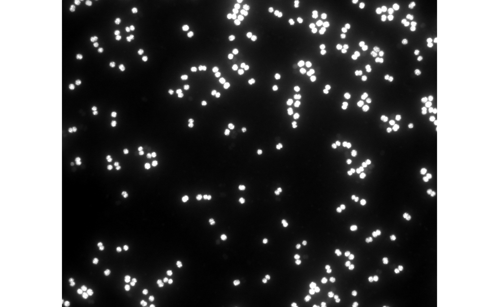

Figure 1: Converted greyscale image of *Microcystis* sp.

The *mapped* function is used to turn 8-bit images into a data matrix from the dimensions of the initial image, using the “*as.matrix*” function (see the *data.table* package), and includes a pixel intensity threshold adjustment. This removes any pixel that is under the threshold value to easily separate the background from cells.

```r
mapped <- function(x, threshold = 0.3) {
  x <- as.matrix(x)
  x[x < threshold] <- 0
  return(x)
}
```

```r
border <- function(x, y) {
  c(x[1:y[1], 1], x[1:y[1], y[2]], x[1, 1:y[2]], x[y[1], 1:y[2]])
}
```

The *single_cell_convert* functions take the data matrices corresponding to each image and counts individual cells within an image, omitting the cells indentified from the *border* function. Fluorescence microscopy images analyzed by this function are of a single fluorescent dimension (i.e. auto-fluorescence, DAPI, etc.). End-users should note that this function, like the name suggests, is useful only for analyzing images containing single-cell cyanobacteria. *fillHull* is placed first in this function before *watershed* in order to disseminate single-cells with more accuracy. A parallel function in *cellcount*, *filamentous_convert*, is similarly organized but meant for filamentous or colonial-type cyanobacteria. The difference with this is largely where *watershed* is placed before *fillHull*, opposite of *single_cell_convert*, which improves accuracy. Within these two functions, several variables can be adjusted by end-users, such as the width and height of the rectangular window (see *EBImage*), the pixel area threshold (i.e., removes cells or other objects under a certain pixel area), and the tolerance and ‘ext’ variables (see *EBImage*).

```r
single_cell_convert <- function(x, w = 17, h = 17, offset = 0.001, areathresh = 50, tolerance= 0.5, ext = 1) {
  image <- thresh(x, w = w, h = h, offset = offset)
  image1 <- fillHull(image)
  image2 <- watershed(distmap(image1), tolerance = tolerance, ext = ext)
  nf <- computeFeatures.shape(image2)
  nr <- which(nf[, "s.area"] < areathresh)
  image3 <- rmObjects(image2, nr)
  return(image3)
}
```

```r
filamentous_convert <- function(x, w = 17, h = 17, offset = 0.001, areathresh = 50, tolerance= 0.5, ext = 1) {
  image <- thresh(x, w = w, h = h, offset = offset)
  image1 <- watershed(distmap(image), tolerance = tolerance, ext = ext)
  image2 <- fillHull(image1)
  nf <- computeFeatures.shape(image2)
  nr <- which(nf[, "s.area"] < areathresh)
  image3 <- rmObjects(image2, nr)
  return(image3)
}
```

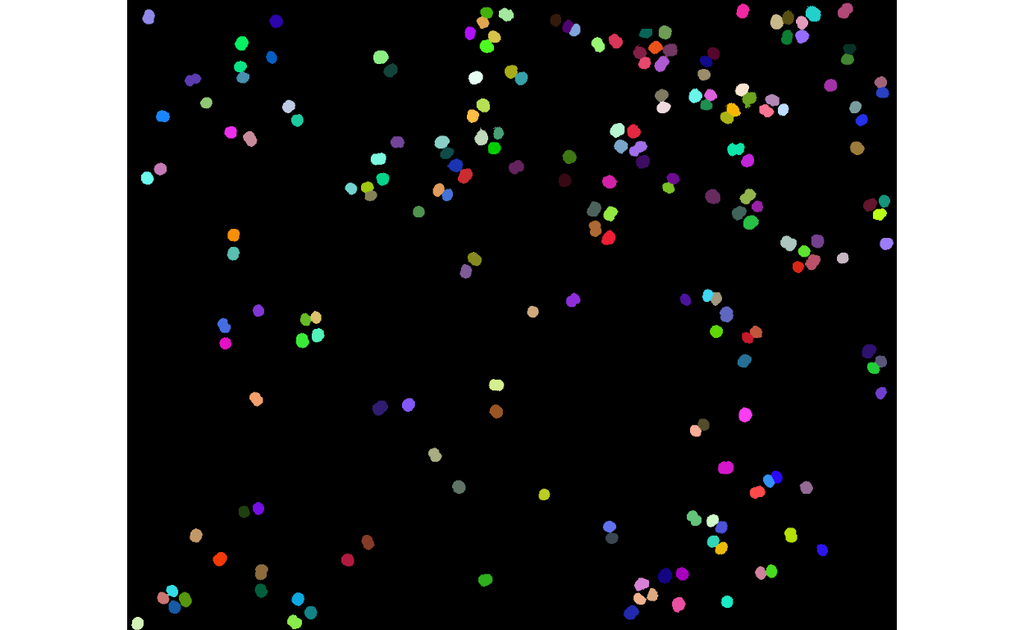

Figure 2: A converted color-label image of *Microcystis* sp.

```r
count_images <- function(image, normalize = TRUE, removeEdgeCells = TRUE) {
  if (removeEdgeCells) {
    dims <- dim(image)
    border1 <- border(image, dims)
    ids <- unique(border1[which(border1 != 0)])
    inner <- rmObjects(image, ids)
    EBImage::colorLabels(inner, normalize = normalize)
  } else {
    EBImage::colorLabels(image, normalize = normalize)
  }
}
```

The final function, *count_cells*, counts the number of cells resulting from the image generated by the *count_images* function. Once again, the *border* function is integrated here to omit counting cells within its predetermined border. Other items within the *sandbox_analysis_test.R* script enables users to analyze images in bulk, generate tables of results, calculate cell densities using equations from (Wetzel and Likens 2000), and export data to .csv files for easy organization.

```r
count_cells <- function(x) {
  countAll <- max(x)
  dims <- dim(x)
  border1 <- border(x, dims)
  ids <- unique(border1[which(border1 != 0)])
  countInner <- countAll - length(ids)
  return(countInner)
}
```

Table 1: Analyzed results from test images of *Microcystis* sp.

| Image_File_Name | Cell_Count |
| --- | --- |
| F192_Microcystis_Demo_01.tif | 207 |
| F192_Microcystis_Demo_02.tif | 183 |
| F192_Microcystis_Demo_03.tif | 238 |
| F192_Microcystis_Demo_04.tif | 219 |
| F192_Microcystis_Demo_05.tif | 196 |
| F192_Microcystis_Demo_06.tif | 216 |
| F192_Microcystis_Demo_07.tif | 206 |
| F192_Microcystis_Demo_08.tif | 223 |
| F192_Microcystis_Demo_09.tif | 216 |
| F192_Microcystis_Demo_10.tif | 229 |
| Cell Total | 2133 |
| Imaging Average | 213.3 |
| Cell Density | 2918626.56 |
| Cells per mL | 583725.312 |

# Graphical user interface using Shiny apps

Informal discussions with researchers ignited the development of a graphical user interface (GUI) using Shiny apps, paired with functions from the *cellcount* package. This results in the use of two functions, *input_data_GUI* and *analyze images_GUI*, to run the entire analysis process as outlined in the *sandbox_analysis_test.R* script. In addition to packages required by *cellcount*, these GUIs require the *shiny* (Chang et al. 2022), *shinyalert* (Attali, Edwards, and Wang 2021), *shinyFiles* (Pedersen et al. 2022), *shinyjs* (Attali 2021), *DT* (Xie et al. 2023), and *beepr* (Baath and Dobbyn 2018) libraries.

*input_data_GUI* uses a Shiny app UI for end-users to easily fill out the needed information in order to correctly label analyzed images, provide numerical inputs for variables, select image analysis type, and easily select directories containing images and saving data. The UI format is a simple approach, with tabs outlined on the left-hand side of the interface for its respective purpose (i.e., directory selection, analysis type selection, etc.). Each tab contains interactive buttons or drop-down menus for users to enter in the respective information or make appropriate selections for their analysis needs. Shiny directory buttons provide users a simple and familiar interface to select appropriate folders containing images or to set up save directories. Alert modals (see *shinyalert*) are used for users to interact and provide information in text format, with helpful dialog to keep users organized and informed of the information needed. Once all information is provided, users select the “Completion” tab and click the “submit data entries” button to complete the data input process.

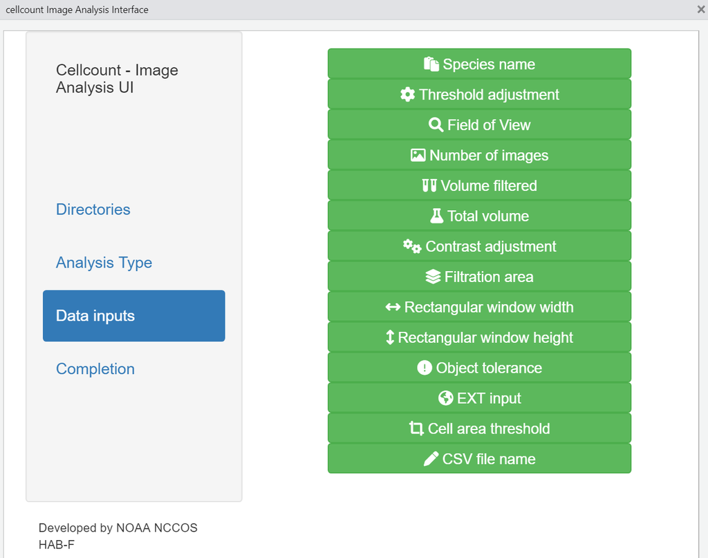

Graphical user interface of the ‘input_data’ function using Shiny

*analyze_images_GUI* uses a simplistic Shiny UI which consists of three buttons, one to run the analysis, another to close the UI interface, and one to refresh the available data table below once the analysis has completed. Once the proper data has been entered from the *input_data_GUI* function, users simply click the “Run Image Analysis” button to begin. Sounds from the *beepr* package alert users of completion of the analysis, allowing users to refresh the data table to see their results. Once satisified, users can click the “Close window” button to exit the UI window. Users can navigate to their specific directories to find analyzed images and related .csv files for their review.

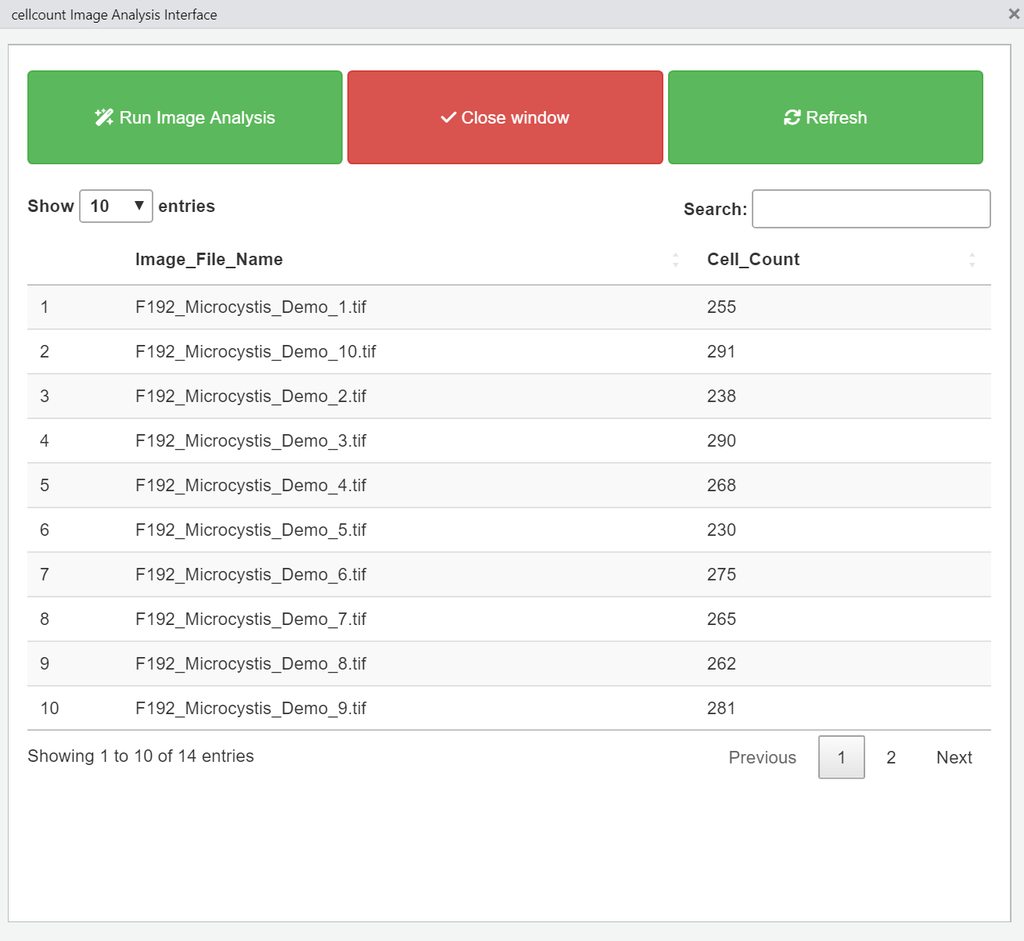

Graphical user interface of the ‘analyze_images’ function using Shiny

# Limitiations and warnings

The current version of this package may be limited for some users regarding processing power. Analysis with this package uses local memory, which may be limiting if expected to analyze large amounts of images in batches. We recommend at least 16GB of localized RAM, the use of a cloud computing supercomputer, or organize images in easier-to-analyze batches to reduce local memory strain.

Users must be aware that this package does not contain abilities to identify distinct cells. The development of this package utilized carefully cultured monoculture of various cyanobacteria species. Users may find difficulty in using this analysis tool if cultures contain heavy amounts of particulates, other cellular debris, and contamination of other species. It is advised to use this tool for single-species only. Future developments of this tool include identifying features and building image libraries of specific cellular species for use in environmental samples.

Outside of package limitations, users must be aware of limitations that may arise from poor microscopy imaging; reduce lighting as much as possible, avoid heavy background fluorescence, and so forth. Good images produce good results - keep this in mind as you utilize this tool.

# Conclusions

*cellcount* provides an open-source approach to cyanobacteria enumeration that is accurate and rapid compared to standardized microscopy methods. The open-source approach allows researchers to access this tool for free and to modify and make additions the existing code to fulfill their particular needs, whereas the Shiny GUI allows users of all coding backgrounds to utilize this analysis tool.

# Acknowledgements

# Literature Cited

Attali, D. 2021. “Shinyjs: Easily Improve the User Experience of Your Shiny Apps in Seconds.” https://cran.r-project.org/web/packages/shinyjs/index.html.

Attali, D., T. Edwards, and Z. Wang. 2021. “Shinyalert: Easily Create Pretty Popup Messages (Modals) in Shiny.” https://cran.r-project.org/web/packages/shinyalert/index.html.

Baath, R., and A. Dobbyn. 2018. “Beepr: Easily Play Notification Sounds on Any Platform.” https://cran.r-project.org/web/packages/beepr/index.html.

Bivand, R., F. Leisch, and Martin Maechler. 2021. “Bitmap Images/Pixel Maps, R Package Version 0.4.12.” https://cran.r-project.org/package=pixmap.

Borges, H.D., R.E. Cicerelli, T. de Almeida, H.L. Roig, and D. Olivetti. 2019. “Monitoring Cyanobacteria Occurrence in Freshwater Reservoirs Using Semi-Analytical Algorithms and Orbital Remote Sensing.” *Marine and Freshwater Research* 71 (5): 569–78. https://doi.org/10.1071/MF18377.

Carey, C.C., B.W. Ibelings, E.P. Hoffmann, D.P. Hamilton, and J.D. Brookes. 2012. “Eco-Physiological Adaptations That Favour Freshwater Cyanobacteria in a Changing Climate.” *Water Research* 46 (5): 1394–1407. https://doi.org/10.1016/j.watres.2011.12.016.

Catherine, Q., W. Susanna, E.S. Isidora, H. Mark, V. Aurelie, and H. Jean-Francois. 2013. “A Review of Current Knowledge on Toxic Benthic Freshwater Cyanobacteria - Ecology, Toxin Production and Risk Management.” *Water Research* 47 (15): 5464–79. https://doi.org/10.1016/j.watres.2013.06.042.

Chang, W., J. Cheng, J. Allaire, M. Boutros, and W. Huber. 2022. “Shiny: Web Application Framework for R.” https://cran.r-project.org/web/packages/shiny/index.html.

Hijmans, R.J, J. van Etten, M. Sumner, J. Cheng, D. Baston, A. Bevan, R. Bivand, et al. 2023. “Raster: Geographic Data Analysis and Modeling.” https://cran.r-project.org/web/packages/raster/index.html.

Jin, C., M.M.F. Mesquita, J.L. Deglint, M.B. Emelko, and A. Wong. 2018. “Quantification of Cyanobacterial Cells via a Novel Imaging-Driven Technique with an Integrated Fluorescence Signature.” *Scientific Reports* 8 (June). https://doi.org/10.1038/s41598-018-27406-0.

Kurmayer, R., G. Christiansen, and I. Chorus. 2003. “The Abundance of Microcystin-Producing Genotypes Correlates Positively with Colony Size in Microcystis Sp. And Determines Its Microcystin Net Production in Lake Wannsee.” *Applied and Evnrionmental Microbiology* 69 (2): 787–95. https://doi.org/10.1128/AEM.69.2.787-795.2003.

Li, M., W. Zhu, and L. Gao. 2014. “Analysis of Cell Concentration, Volume Concentration, and Colony Size of Microcystis Via Laser Particle Analyzer.” *Environmental Management* 53 (February): 947–58. https://doi.org/10.1007/s00267-014-0252-8.

Pau, G., F. Fuchs, O. Skylar, M. Boutros, and W. Huber. 2010. “EBImage—an R Package for Image Processing with Applications to Cellular Phenotypes.” *Bioinformatics* 26 (7): 979–81. https://doi.org/10.1093/bioinformatics/btq046.

Pedersen, T.L., V. Nijs, T. Schaffner, and E. Nantz. 2022. “shinyFiles: A Server-Side File System Viewer for Shiny.” https://cran.r-project.org/web/packages/shinyFiles/index.html.

Pokrzywinski, K., B.M. Boyd, and S.J. Smith. 2019. “A High-Throughput Method for Counting Cyanobacteria Using Fluorescence Microscopy.” https://doi.org/10.21079/11681/33870.

Schulze, K., D.A. Lopez, U.M. Tillich, and M. Frohme. 2011. “A Simple Viability Analysis for Unicellular Cyanobacteria Using a New Autofluorescence Assay, Automated Microscopy, and ImageJ.” *BMC Biotechnology* 11 (118). https://doi.org/10.1186/1472-6750-11-118.

Stauffer, B.A., H.A. Bowers, E. Buckley, T.W. Davis, T.H. Johengen, R. Kudela, M.A. McManus, et al. 2019. “Considerations in Harmful Algal Bloom Research and Monitoring: Perspectives From a Consensus-Building Workshop and Technology Testing.” *Frontiers in Marine Science* 6 (399). https://doi.org/10.3389/fmars.2019.00399.

Stumpf, R.P., T.T. Wynne, D.B. Baker, and G.L. Fahnenstiel. 2012. “Interannual Variability of Cyanobacterial Blooms in Lake Erie.” *PLoS One* 7 (8): e42444. https://doi.org/10.1371/journal.pone.0042444.

Urbanek, S., and K. Johnson. 2022. “Tiff: Read and Write TIFF Images. R Package Version 0.1-11.” https://www.rforge.net/tiff/.

Wetzel, R.G., and G.E. Likens. 2000. *Limnological Analyses - 3rd Edition*. https://doi.org/10.1007/978-1-4757-3250-4.

Wood, S.A., L. Kelly, K. Bouma-Gregson, J.F. Humbert, H.D. Laughinghouse, J. Lazorchak, T. McAllister, et al. 2020. “Toxic Benthic Freshwater Cyanobacterial Proliferations: Challenges and Solutions for Enhancing Knowledge and Improving Monitoring and Mitigation.” *Freshwater Biology* 65 (10): 1824–42. https://doi.org/10.1111/fwb.13532.

Xie, Y., J. Cheng, X. Tan, J.J. Allaire, M. Girlich, G.F. Ellis, J. Rauh, et al. 2023. “DT: A Wrapper of the JavaScript Library DataTables.” https://cran.r-project.org/web/packages/DT/index.html.